# Gender Pay Gap

Ross McCullough - Group 9

09/10/2022

### Imports

```r
library(tidyverse)
library(lubridate)
library(rmarkdown)
library(knitr)

#Set printed table options to a number that is not computationally limiting
options(max.print = 100)
```

## Load Data

### Load Yearly Pay Gap Data

Gender pay gap data is provided for a number of years. All data is stored to the `./data` folder. `glob` is used to find the files and they are concatenated into to a dataframe.

```r
#List file is data dir matching pattern
gender_paygap_year_files <-
  Sys.glob("./data/UK Gender Pay Gap Data -*.csv")

#empty dataframe to append to
all_year_df <- tibble()

#for loop to run over file, read and concat
for (csv in gender_paygap_year_files){
  year_df <- read_csv(csv)
  all_year_df <- rbind(all_year_df, year_df)
}
```

It will be useful to be able to access the year later for analysis. This is pulled from the survey due date column, though there may be more reliable options, such as from the file path.

```r
# Get the year from the due date
all_year_df <-
  all_year_df %>%
  mutate(year = year(DueDate))
```

A summary of the data is shown below

```r
paged_table(all_year_df)
```

| EmployerName | EmployerId | Address | PostCode | CompanyNumber | SicCodes | DiffMeanHourlyPercent | DiffMedianHourlyPercent | DiffMeanBonusPercent | DiffMedianBonusPercent | MaleBonusPercent | FemaleBonusPercent | MaleLowerQuartile | FemaleLowerQuartile | MaleLowerMiddleQuartile | FemaleLowerMiddleQuartile | MaleUpperMiddleQuartile | FemaleUpperMiddleQuartile | MaleTopQuartile | FemaleTopQuartile | CompanyLinkToGPGInfo | ResponsiblePerson | EmployerSize | CurrentName | SubmittedAfterTheDeadline | DueDate | DateSubmitted | year |
| --- | --- | --- | --- | --- | --- | --- | --- | --- | --- | --- | --- | --- | --- | --- | --- | --- | --- | --- | --- | --- | --- | --- | --- | --- | --- | --- | --- |
| "Bryanston School",Incorporated | 676 | Bryanston House, Blandford, Dorset, DT11 0PX | DT11 0PX | 00226143 | 85310 | 18.0 | 28.2 | 0.0 | 0.0 | 0.0 | 0.0 | 24.4 | 75.6 | 50.8 | 49.2 | 49.2 | 50.8 | 51.5 | 48.5 | https://www.bryanston.co.uk/employment | Nick McRobb (Bursar and Clerk to the Governors) | 500 to 999 | BRYANSTON SCHOOL INCORPORATED | FALSE | 2018/04/05 00:00:00 | 2018/03/27 11:42:49 | 2018 |
| "RED BAND" CHEMICAL COMPANY, LIMITED | 16879 | 19 Smith's Place, Leith Walk, Edinburgh, EH6 8NU | EH6 8NU | SC016876 | 47730 | 2.3 | -2.7 | 15.0 | 37.5 | 15.6 | 66.7 | 20.3 | 79.7 | 25.4 | 74.6 | 10.3 | 89.7 | 18.1 | 81.9 | NA | Philip Galt (Managing Director) | 250 to 499 | "RED BAND" CHEMICAL COMPANY, LIMITED | FALSE | 2018/04/05 00:00:00 | 2018/03/28 16:44:25 | 2018 |
| 123 EMPLOYEES LTD | 17677 | 34 Roundhay Road, Leeds, England, LS7 1AB | LS7 1AB | 10530651 | 78300 | 41.0 | 36.0 | -69.8 | -157.2 | 50.0 | 73.5 | 0.0 | 100.0 | 2.0 | 98.0 | 11.0 | 89.0 | 23.0 | 77.0 | NA | Chloe Lines (Financial Controller) | 250 to 499 | 123 EMPLOYEES LTD | TRUE | 2018/04/05 00:00:00 | 2018/05/04 11:24:06 | 2018 |
| 1610 LIMITED | 682 | Trinity Sports And Leisure, Chilton Street, Bridgwater, England, TA6 3JA | TA6 3JA | 06727055 | 93110 | -22.0 | -34.0 | -47.0 | -67.0 | 25.0 | 75.0 | 56.0 | 44.0 | 52.0 | 48.0 | 30.0 | 70.0 | 24.0 | 76.0 | https://www.1610.org.uk/gender-pay-gap/ | Tim Nightingale (CEO) | 250 to 499 | 1610 LIMITED | TRUE | 2018/04/05 00:00:00 | 2018/04/12 17:03:26 | 2018 |
| 1879 EVENTS MANAGEMENT LIMITED | 17101 | The Sunderland Stadium Of Light, Sunderland, Tyne And Wear, SR5 1SU | SR5 1SU | 07743495 | 56210,\n70229 | 13.4 | 8.1 | 41.4 | 43.7 | 8.7 | 3.2 | 29.1 | 70.9 | 49.4 | 50.6 | 22.8 | 77.2 | 58.2 | 41.8 | https://www.safc.com/news/club-news/2018/march/gender-pay-gap-reporting | Jo Graham (Deputy HR Manager) | 250 to 499 | 1879 EVENTS MANAGEMENT LIMITED | FALSE | 2018/04/05 00:00:00 | 2018/03/29 15:32:33 | 2018 |
| 1LIFE MANAGEMENT SOLUTIONS LIMITED | 687 | Ldh House St Ives Business Park, Parsons Green, St. Ives, Cambridgeshire, PE27 4AA | PE27 4AA | 02566586 | 93110,\n93130,\n93290 | 15.1 | 2.8 | 77.6 | 71.2 | 5.8 | 4.2 | 42.6 | 57.4 | 45.2 | 54.8 | 46.8 | 53.2 | 35.5 | 64.5 | http://www.1life.co.uk/gender-pay-gap | Mark Braithwaite (Managing Director) | 500 to 999 | 1LIFE MANAGEMENT SOLUTIONS LIMITED | FALSE | 2018/04/05 00:00:00 | 2018/03/07 12:01:05 | 2018 |
| 1ST HOME CARE LTD. | 17484 | Real Life Options, 35 East Port, Dunfermline, Fife, Scotland, KY12 7LG | KY12 7LG | SC272838 | 86900,\n88100 | 15.0 | 0.0 | 0.0 | 0.0 | 0.0 | 0.0 | 10.0 | 90.0 | 9.0 | 91.0 | 10.0 | 90.0 | 9.0 | 91.0 | https://www.1sthomecare.co.uk | John McDonald (Executive Director) | 250 to 499 | 1ST HOME CARE LTD. | FALSE | 2018/04/05 00:00:00 | 2018/04/04 12:28:10 | 2018 |
| 1STOP HALAL LIMITED | 689 | Colmore Court, 9 Colmore Row, Birmingham, West Midlands, B3 2BJ | B3 2BJ | 08929070 | 56290 | 11.9 | 0.0 | 0.0 | 0.0 | 0.0 | 0.0 | 75.3 | 24.7 | 52.3 | 47.7 | 58.1 | 41.9 | 69.8 | 30.2 | NA | Stephen Elder (Finance Director) | 250 to 499 | SHAZAN FOODS LIMITED | FALSE | 2018/04/05 00:00:00 | 2018/03/22 08:08:33 | 2018 |
| 2 AGRICULTURE LIMITED | 14399 | Fairview Mill, Ingliston, Newbridge, Midlothian, EH28 8NB | EH28 8NB | SC156515 | 1470,\n10910 | 13.4 | 8.5 | 62.9 | 0.0 | 89.7 | 73.3 | 89.1 | 10.9 | 95.3 | 4.7 | 98.5 | 1.5 | 93.8 | 6.2 | http://www.2agriculture.com/ | Gavin Berry (Managing Director) | 250 to 499 | 2 AGRICULTURE LIMITED | FALSE | 2018/04/05 00:00:00 | 2018/03/22 10:46:20 | 2018 |
| 2 SISTERS FOOD GROUP LIMITED | 77 | Trinity Park House Trinity Business Park, Fox Way, Wakefield, West Yorkshire, WF2 8EE | WF2 8EE | 02826929 | 10120 | 15.3 | 6.9 | 55.5 | 1.6 | 5.6 | 5.1 | 44.9 | 55.1 | 67.6 | 32.4 | 66.2 | 33.8 | 73.7 | 26.3 | https://www.2sfg.com/about-us/how-we-work/gender/ | Nigel Perry (Group People & Change Director) | 5000 to 19,999 | 2 SISTERS FOOD GROUP LIMITED | FALSE | 2018/04/05 00:00:00 | 2018/03/27 14:54:56 | 2018 |

[output cut: 90 more lines]

### Load University Data

Ingest the universities data that designates whether the university was established pre 1992

```r
universities_df <-
  read_csv("./data/universities.csv")
paged_table(universities_df)
```

| EmployerName | EmployerId | pre92 |
| --- | --- | --- |
| Arts University Bournemouth | 12194 | no |
| Bournemouth University | 15721 | no |
| De Montfort University | 3966 | no |
| Durham University | 14890 | yes |
| Imperial College London | 6539 | yes |
| Lancaster University | 16588 | yes |
| Middlesex University | 8438 | no |
| Newcastle University | 14422 | yes |
| ROEHAMPTON UNIVERSITY | 10587 | no |
| THE UNIVERSITY OF BUCKINGHAM | 15516 | yes |

[output cut: 88 more lines]

## Join Data

The data is joined on the `EmployerId` column. This is prefferable to the name column which is suspectible to special characters, case, etc variation

```r
combined_df <-
  inner_join(universities_df,
             all_year_df,
             by="EmployerId")
```

## Analyse

### Contingency Tables

A contigency table of submissions by year (row) with `pre92` status (column).

```r
contigency_df<-
  combined_df %>%
  group_by(year)%>%
  count(pre92) %>%
  pivot_wider(values_from = n, names_from = pre92)

kable(contigency_df)
```

| year | no | yes |
| --- | --- | --- |
| 2018 | 59 | 36 |
| 2019 | 60 | 36 |
| 2020 | 56 | 36 |
| 2021 | 62 | 36 |
| 2022 | 62 | 36 |

### Universties Submissions by Year

Total submissions by year. A possible drop of is seen around 2020.

```r
employee_ids <- universities_df$EmployerId

year_counts <-
  all_year_df %>%
  filter(EmployerId %in% employee_ids)%>%
  group_by(year)%>%
  count()

kable(year_counts)
```

| year | n |
| --- | --- |
| 2018 | 95 |
| 2019 | 96 |
| 2020 | 92 |
| 2021 | 98 |
| 2022 | 98 |

### Summary Statistic

```r
summary_df <-
  combined_df %>%
  group_by(year)%>%
  summarise(min(DiffMedianHourlyPercent), mean(DiffMedianHourlyPercent), max(DiffMedianHourlyPercent))

kable(summary_df)
```

| year | min(DiffMedianHourlyPercent) | mean(DiffMedianHourlyPercent) | max(DiffMedianHourlyPercent) |
| --- | --- | --- | --- |
| 2018 | -2.5 | 16.74211 | 37.4 |
| 2019 | -5.3 | 15.15729 | 48.4 |
| 2020 | -1.6 | 14.71413 | 42.9 |
| 2021 | -3.4 | 14.24388 | 37.1 |
| 2022 | 0.0 | 12.94082 | 41.0 |

### Visulations - Boxplot Median Payt Difference by Year

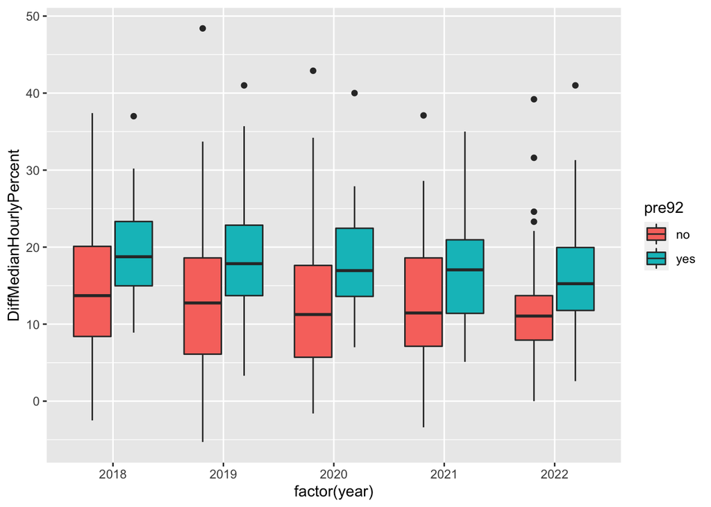

```r
ggplot(data = combined_df, aes(x=factor(year), y=DiffMedianHourlyPercent, fill=pre92))+
  geom_boxplot()
```